# Cloud Based Personal Spending Application hosted through AWS

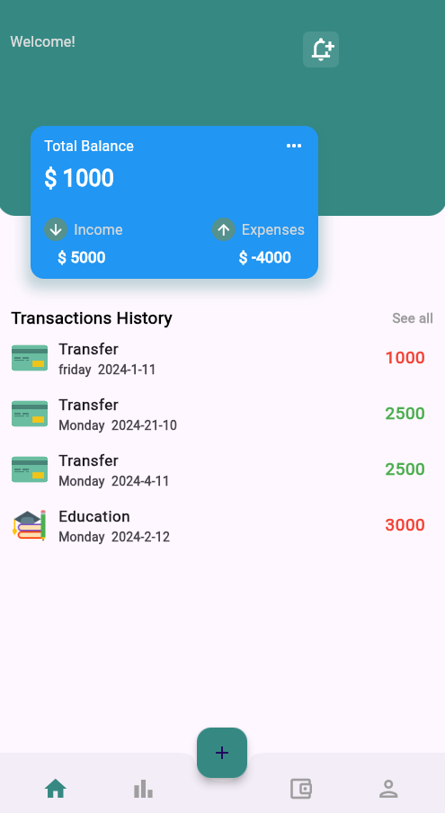

### Introduction

This report consolidates the journey of developing a cloud-based personal speding management application. The project was originally aimed to create a platform where users could manage their financial lives through tools for budgeting, expense tracking, investment monitoring, and personal finance advising, but a lot of planned features ended up being cut due to the amount of time it would take to implement; that, along with this project being my first ever software application and web project. The application leverages Flutter for development and cloud infrastructure to ensure scalability, security, and performance. This report traces the project’s progression from ideation to completion, detailing the key decisions, technologies, and methodologies adopted throughout.

# Project Concept and Planning

The application’s core objective was to offer users real-time insights and tools for financial management. Key features included linking bank accounts and credit cards, setting budgets, and analyzing spending habits. The monetization model included a free version with basic features and advertisements and a premium version offering advanced analytics and investment advising. Below is the C4 diagram I initially constructed in the planning stages of development:

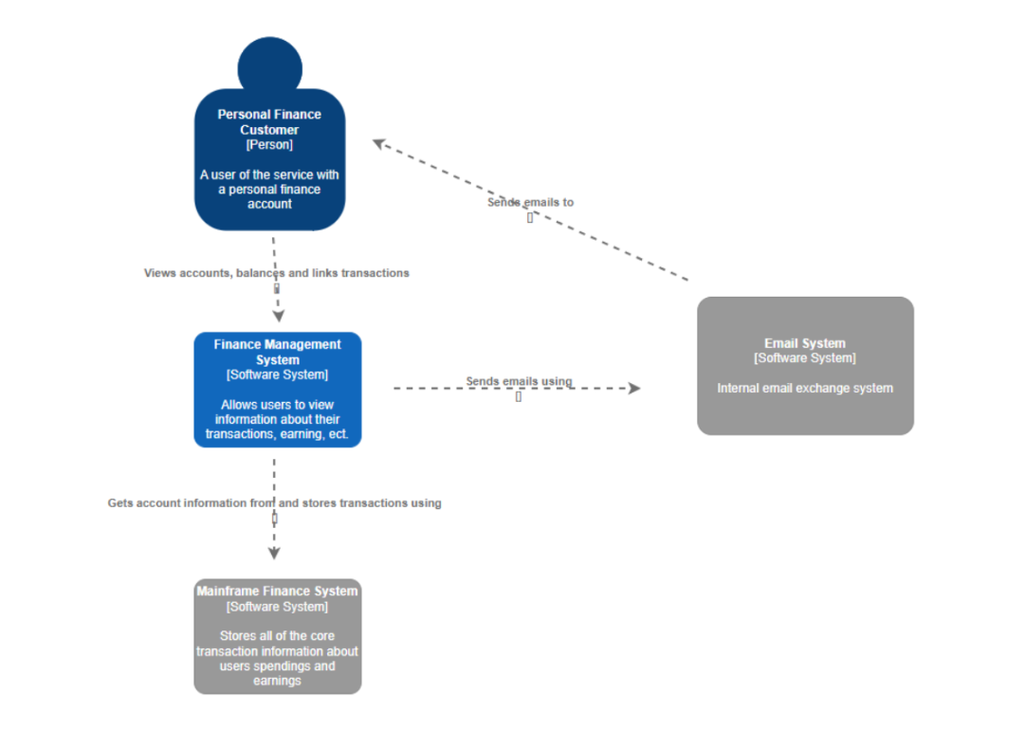

# Cloud Provider Evaluation:

To determine the optimal cloud provider, a comparative analysis of AWS, Microsoft Azure, and Google Cloud Platform (GCP) was conducted. AWS was chosen for its extensive service offerings, robust ecosystem, and proven scalability. While Azure excelled in security and Microsoft 365 integration, and GCP in low-latency data transfer, AWS’s flexibility and broad compatibility made it the most suitable for a start-up environment.

# Compute Resource Selection

To handle the dynamic workload of the application, serverless computing via AWS Lambda was selected. This approach ensured automatic scaling based on demand and cost-efficiency by charging only for actual usage. Serverless architecture eliminated the need for infrastructure management, enabling the team to focus on application functionality rather than operational overhead. In comparison, traditional virtual machines and containerized environments were deemed less efficient and more resource-intensive for this use case.

# Web Hosting Solution

Given the need for scalability, security, and ease of management, the application’s web version employed an HTTP Web API Gateway. This solution balanced the strengths of Platform-as-a-Service (PaaS) and Infrastructure-as-a-Service (IaaS). While PaaS streamlined development and scaling, and IaaS offered flexibility, the API Gateway provided robust security and simplified high-traffic handling. This approach minimized management complexity and operational costs, aligning well with the start-up’s limited resources. Below is the diagram I constructed during this stage of planning:

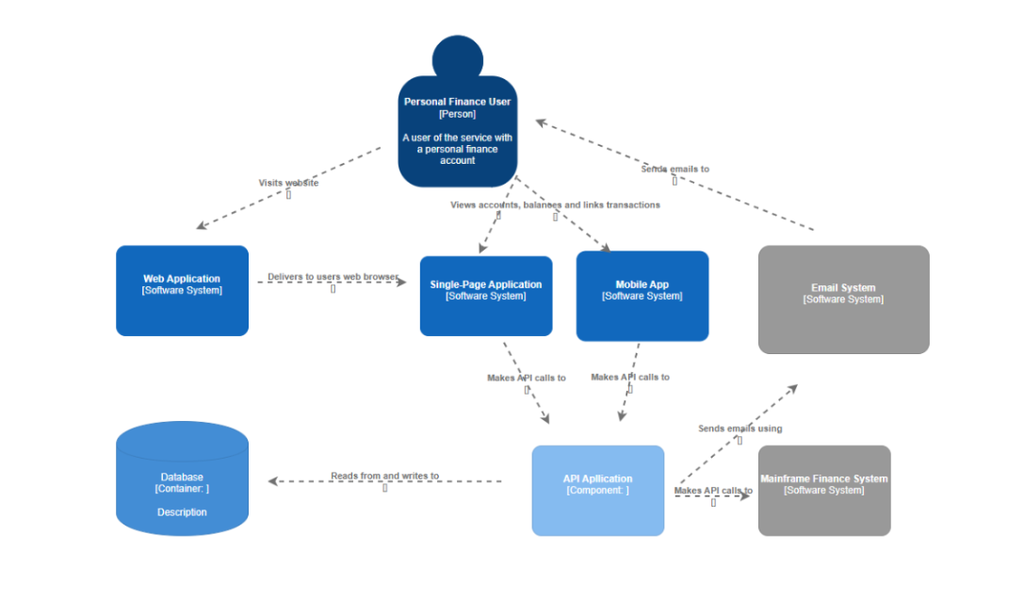

# Database Design

The application’s data, being structured and relational, necessitated a relational database solution. AWS Aurora was chosen for its scalability, high performance, and automated management features. Aurora’s ability to optimize query performance and handle real-time financial tracking made it an ideal choice. While NoSQL solutions excel in handling unstructured data, they were unsuitable for this application’s structured financial data requirements.

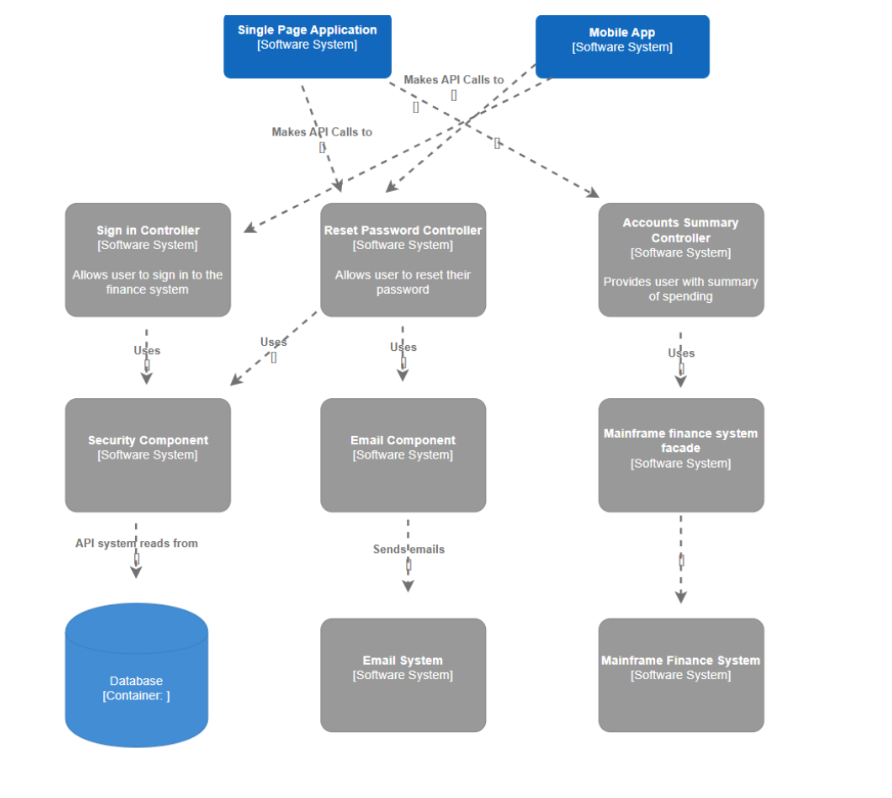

# Communication Protocol

The application utilized REST as the primary communication protocol. REST’s simplicity, compatibility with HTTPS, and stateless architecture ensured secure, scalable interactions for operations like retrieving financial data and managing user profiles. Alternatives such as WebSockets and gRPC were considered but found less suitable due to their complexity and resource intensity. Webhooks, while lightweight, lacked the immediacy required for certain operations.

# Architectural Pattern

For collaborative features such as real-time notifications, an Event-Driven Architecture was adopted. This pattern decouples components, enhancing scalability and flexibility. Event producers and consumers communicate via brokers like Apache Kafka or AWS SNS, ensuring reliable message delivery and responsiveness. Compared to Microservices or Serverless architectures, Event-Driven Architecture offers superior handling of asynchronous, high-throughput tasks, making it optimal for real-time updates.

# Flutter Development

The application’s user interface and functionality were developed using Flutter. This choice ensured cross-platform compatibility, rapid development, and a consistent user experience across devices. Learning how to create applications with Flutter was an amazing opportunity as I believe that it is a skill that is very valuable to manty employers.

# Challenges and Lessons Learned

- Working with SDK, JDK, Gradle, Android Studio and Flutter: Understanding and researching how to get everything to work setting up the project environment took a considerable amount of time. A lot of the guides that we consolidated were out of date and there were many problems that had to be resolved that were simply not easily findable on the internet. Troubleshooting these problems definitely took up most of the time developing the project, but the knowledge on how to traverse these issues is something that may be very useful in future projects.
- Successfully deploying application to the cloud: Troubleshooting the requirements necessary for hosting the project on AWS proved to be especially difficult, mostly due to the same reasons listed above; there were many outdated guides and the advice on Amazon’s website was not exactly easy to follow
- Scalability and Cost Management: Serverless architecture significantly reduced operational costs but required meticulous monitoring to avoid unexpected expenses due to high traffic.
- Security Concerns: Handling sensitive financial data demanded rigorous adherence to compliance standards and implementation of robust encryption protocols.
- Integration Complexities: Linking multiple third-party services, such as bank APIs, introduced challenges in maintaining data consistency and synchronization.

# Possible Future Implementatios

- Enhanced Analytics: Incorporating machine learning models for predictive financial insights.
- Stock management system
- System that allows users to pay off their credit cards in the app rather than having to go to each corresponding app and pay off cards individually
- Recommendation system that would help users see where they can cut costs
- Global Reach: Expanding infrastructure to support international users with localized features.
- Advanced Security: Continuous updates to security measures to address emerging threats and maintain user trust.

# Conclusion

This cloud-based personal finance management application represents a comprehensive integration of modern technologies, cloud computing paradigms, and user-centric design. By leveraging AWS, Flutter, and thoughtful architectural choices, the project achieved a scalable, secure, and efficient solution. This experience I gained developing this project has been such a great learning experience for me. Before starting this project (and class) the concept of developing a cloud application from scratch sounded very scary and very difficult, but understanding each of the components bit by bit made this project doable. I am confident that I could accomplish even more if I were to create another cloud-based application in the future.

# More screenshots of application

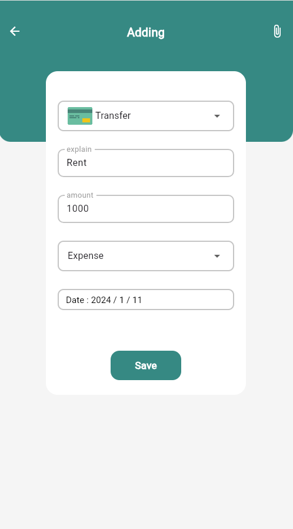

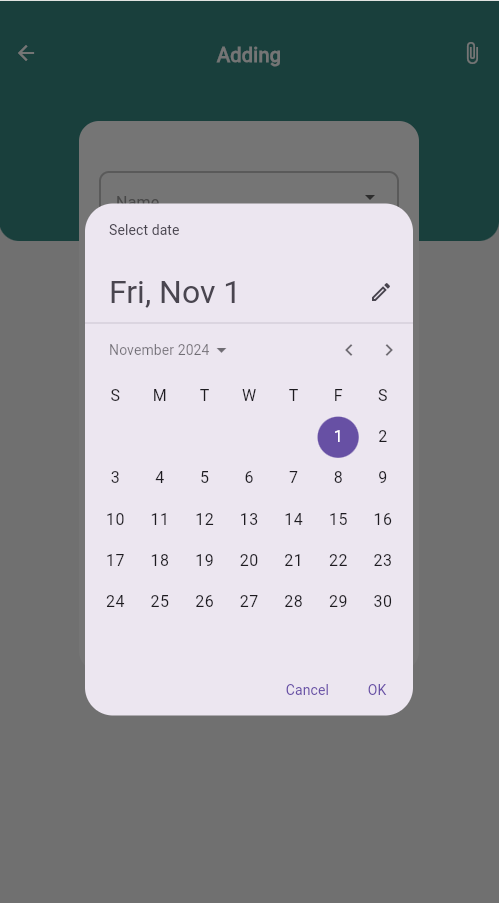

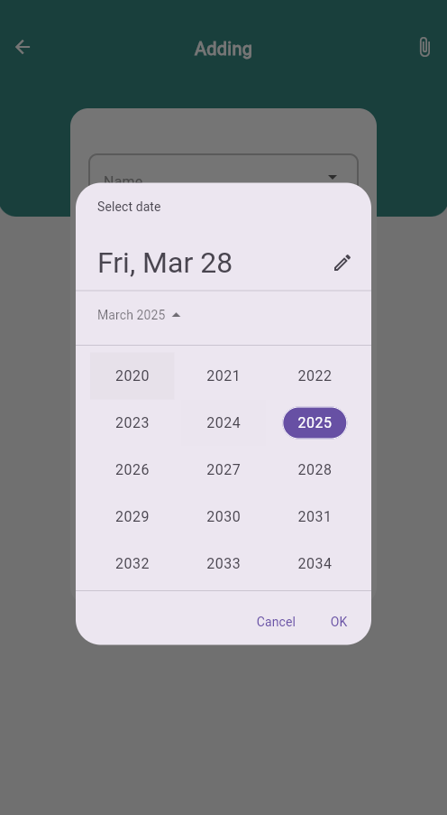

```python
!jupyter nbconvert --to html cloudapp.ipynb
```

[output not shown]